Skip to the study

MONTREAL.AI RESEARCH EDITION · 27 OCTOBER 2026

TRANSFORMATIONAL INTELLIGENCE: LEARNING TO CHANGE THE GAME

# AGI ALPHA FLYWHEEL — When Capability Creates Opportunity

Transformational Intelligence, Experience-Trained Specialists and the Expanding Frontier of Profitable Work

Vincent Boucher — President of MONTREAL.AI

FIND YOUR ALPHA. BUILD YOUR SUCCESSOR Ω.

Read the PDF Explore the English / Français demo Executive brief Evidence companion

Executed software · synthetic missions and markets · no live customer receipts or spacecraft authority

# 1 Research finding

**A reusable instrument can make a conditional shared service explicit and testable; its commercial value still has to survive fresh work.** This study constructs and executes a finite observation-and-contingency compiler. Its originating example asks whether three satellite operators could share the cost of learning more about a common uncertain object while preserving each operator’s risk criterion, action deadline and fallback funding. The software produces inspectable branch plans, transfers through the existing AGI ALPHA lifecycle, and runs in a separate recipient process.

The originating example supports a narrow positive result. Under frozen, explicitly hypothetical prices and behavior, individual observation purchases attract no orders, while the joint offer has expected service collections of **$157.30**, complete cash operating costs of **$134.47**, and operating contribution of **$22.83** before optional retention or extra research. The conventional expert, given the same information and coordination rights, ties this result. A fully successful branch earns $105; it is distinct from the expectation. All monetary amounts are USD.

Fresh evaluation sharply bounds that positive illustration. An independently written exact reference agrees with the frozen compiler on **48 of 48** synthetic missions: 36 valid plans and 12 correct refusals. Of the valid plans, 20 have positive aggregate information value, four have zero value and twelve have negative value before acquisition fees. Applying the unchanged commercial policy produces **no acquisition order in any of the 48 cases**. Their modeled preliminary assessment costs total $346. Origin plus confirmation invitations therefore contribute **−$323.17**, before optional B/C investment and any unmeasured research opportunity cost.

The retained executable transfers correctly. Its fresh recipient has positive aggregate information value, but one operator is worse off before fees and the proposed order is economically unjustified. The useful successor decision is to stop that offer. An ordinary directory with identical contents and permissions produces byte-identical results. This establishes executable reuse and fresh semantic checking; additional retained financial advantage remains unmeasured.

The resulting contribution is a complete conditional study: an opportunity hypothesis, a purpose-preserving transformation witness, a usable instrument, independent confirmation, disjoint accounting, actual byte transfer and a justified commercial stop. The constructive lesson is precise: **information quality, buyer participation and available cash must be checked together, branch by branch, before a capability is treated as earned Alpha.**

## 1.1 Evidence at a glance

| Layer | What was actually established |
| --- | --- |
| Execution | Local Python computations, independent rational-arithmetic checks, lifecycle replay and separate recipient execution |
| Domain | Synthetic finite probabilities, action costs and deadlines; no orbital propagation or physical sensor trial |
| Acceptance | Software conformance to the frozen research contract; customer acceptance is modeled |
| Commercial result | Conditional originating offer; negative complete modeled invitation campaign |
| AI operation | AI-assisted construction and review; no metered U/E/E+ frontier-model trial |
| Retention | Actual executable transfer; ordinary-library parity; primary additional investment rejected |
| Collections and cost | Actual customer collections $0; actual complete research cost and profit unknown |

# 2 Opportunity discovery before the benchmark

The initial question was not how to accelerate an existing numerical solver. It was whether several parties could purchase an uncertainty-reducing observation that none would find worthwhile alone, without transferring the observation’s adverse consequences to someone else. The beneficiary would be an operator buying a small, inspectable decision-support package: what can be learned, which actions remain available after each possible result, what must be reserved, and when the proposed acquisition should be refused.

This is a consequential setting with extensive prior art. NASA documents free USSPACECOM screening and validated commercial alternatives, recommends retaining suitable data/actionability checks, and describes a widely used per-event mitigation threshold of $10^{-4}$. That threshold informs the illustrative scale here; our finite inputs do not implement operational NASA conjunction assessment. (NASA Office of the Chief Engineer 2026) ESA’s collision-avoidance challenge concerns evolving risk estimates in CDMs; the final reported risk is not a realized collision label. We did not download or reanalyze that dataset. (Uriot et al. 2020)

## 2.1 Bounded candidate portfolio

Discovery considered four materially different opportunities and their outside options. The dossier and source-access limitations are preserved in the evidence companion.

| Candidate | Consequential possibility | Prior-art challenge and cycle decision |
| --- | --- | --- |
| Shared observation procurement | Several operators benefit from one measurement while preserving individual fallback options | Existing assessment, commercial data and federated coordination prevent broad novelty claims. Select the narrow contingency/participation experiment. |
| Emerging-contaminant pilot procurement | Small utilities jointly acquire sampling and engineering evidence | EPA already offers eligible communities no-cost technical assistance. Paid demand and physical transfer remain unestablished. (US Environmental Protection Agency 2026) |
| Contingent cold-chain service | Preserve useful goods through coordinated sensing, logistics and financing | Existing integrated systems and pilots make a generic simulation a weak discovery claim. Physical evidence was unavailable. (FAO and UNEP 2022) |
| On-board observation contracts | Deliver purpose-specific information under downlink constraints | PhiSat-2 already supplies application chaining and derived products. A distinct unmet niche was not established in this cycle. (European Space Agency 2023) |

The satellite candidate survived as a **conditional construction hypothesis**, not a verified new market. The discovery reviewer also located ESA’s federated-satellite consensus project; the public listing is prior art, not evidence of demand for this package. A later parent retrieval returned HTTP 403, which is retained as an access limitation. (European Space Agency 2021)

The selected commercial gap is therefore an explicit hypothesis: small operators with overlapping information needs may lack an inexpensive, agreed, contingency-complete package and an arrangement that funds it. This study asks what must be true for such an offering to work. It does not infer an unmet market merely from the ability to write software.

The initial effort allocation was 20 minutes for discovery, 35 for implementation, 25 for evaluation and 25 for writing/demonstration. These were planning budgets, not labor bills. A short counterexample and eight development cases preceded the manuscript. The full repository was not rearchitected, no paid API was purchased, and existing study owners were preserved through issue 4850. (MONTREAL.AI 2026b)

# 3 Three foundations, one testable mechanism

The study connects the three requested foundations through a single operating path. *Transformational Intelligence* separates the original purpose from an inherited formulation and requires an executable witness for a changed restriction. Its examples also preserve competent conventional alternatives. (MONTREAL.AI 2026d) *Invent the Economy* treats the capability and the delivery arrangement as a joint object of construction, with participation and liquidity distinct from expected surplus. (MONTREAL.AI 2026a) *SUCCESSOR Ω Harness* preserves stable reusable structure while requiring fresh mission checks and separate authority. (MONTREAL.AI 2026c)

## 3.1 Transformation witness

| Element | Witness in this study |
| --- | --- |
| Original purpose | Produce a decision-support plan satisfying each operator’s original risk threshold, action timing and fallback funding requirement. |
| Binding restriction | Individual acquisition charges exceed each operator’s expected benefit; a favorable mean outcome also hides adverse observation branches. |
| Why it may be removable | Several missions depend on the same observation. Their acquisition expense can be shared while each keeps its own acceptance and fallback conditions. |
| Replacement | A shared conditional order paired with a compiled, operator-specific branch plan and explicit refusal/withdrawal rules. |
| Executable realization | A bounded Bayesian compiler, independent exact checker, finite commercial event ledger and existing lifecycle transfer. |
| Falsifier | A reachable branch violates risk or timing; a buyer has negative participation value; liabilities exceed funding; or the unrestricted conventional expert removes the claimed incremental advantage. |

The purpose is preserved by checking every reachable branch. A plan cannot pass because a favorable branch offsets an unsafe one. A low average cost cannot fund away a participant’s risk obligation. The transformation changes the unit of procurement and the completeness of the plan; it does not claim a new Bayes rule, a new conjunction algorithm or superior performance over an already equipped conventional expert.

## 3.2 Operational Alpha and retained Alpha remain separate

Four configurations organize the evidence:

| Configuration | Definition and evidence here |
| --- | --- |
| **H** | An equivalent human-produced finite decision-support package. Cost is estimated from explicit hours and a sourced wage proxy; no scoped commercial quote was obtained. |
| **U** | Representative ordinary use of the same frontier model, with the same potential tools and permissions. Task performance is an unmeasured parameter. |
| **E** | An expert workflow that formalizes purpose, checks units/scope, computes contingencies, verifies outputs and accounts for failures. The conventional exact planner provides a strong technical reference… |
| **E+** | E plus the retained compiler and scope contract. Actual transfer is executed; incremental labor or financial savings are not assumed. |

The no-construction factorial arm is a component ablation, not U. The flawed timeout calculation is a design challenge, not a representative ordinary user. The unrestricted expert has the same right to pool demand, use ordinary mathematical tools and construct alternatives. This prevents a supplied restriction from becoming a manufactured AI advantage.

# 4 Minimal executable experiment

## 4.1 A finite world with explicit limits

A mission supplies a finite common state $s\in S$, prior $p(s)$, an observation likelihood $L(y\mid s)$, and a delivery time for each possible outcome. Each operator $i$ supplies actions $a\in A_i$, a risk vector $r_i(a,s)$, deterministic action expense $c_i(a)$, an action start limit and an original risk ceiling $\tau_i$. A fixed fallback action applies if observation times out. The implementation permits at most twelve states, twelve outcomes, six operators and six actions per operator.

The inputs are synthetic probability tables. They are not learned sensor calibration, orbital covariances or validated maneuver predictions. Actions have no physical cross-effects in this bounded world. Adding maneuver interactions or a different measurement regime would require a new model and fresh qualification. This narrow scope keeps the causal question inspectable rather than hiding it inside an oversized simulator.

For a timely result $y$, the compiler calculates

$$p(s\mid y)=\frac{p(s)L(y\mid s)}{\sum_{s'}p(s')L(y\mid s')}.$$

It chooses the least expensive action that is still available and satisfies

$$\sum_s p(s\mid y)r_i(a,s)\leq\tau_i.$$

Each operator may have a different observation deadline. Its timeout is the union of no-result outcomes and results arriving after that deadline. Their likelihoods are summed **before** applying Bayes. The declared fallback must satisfy the conditional risk bound and remain available at timeout. Unreachable events remain explicitly unreachable; they are not counted as deliveries.

Observation permission is refused for unusable inputs, uncleared fixture rights or mismatched calibration scope. The output carries the input hash and `execution_authorized=false`; the compiler identity is bound by the frozen source, bundle and transfer receipts. An admissible plan and a valuable purchase are distinct decisions.

## 4.2 The first decisive counterexample

A reviewer proposed the design challenge that missingness can be informative. We executed a two-state example with dangerous-state prior 0.02, risk 0.002 in that state, and timeout likelihoods 0.29 in the dangerous state versus 0.04 in the safe state. A prior-based timeout check gives $0.02\times0.002=0.00004$, below the illustrative limit. Conditioning on timeout gives

$$P(\text{danger}\mid\text{timeout})=
\frac{0.02\times0.29}{0.02\times0.29+0.98\times0.04}=0.128888\ldots,$$

and conditional risk **0.00025778**, above the same limit. A previously acceptable coast action would therefore be wrongly accepted by a prior-only check. The corrected compiler aggregates operator-specific timeout evidence and preserves a safe fallback. This was a researcher/reviewer design revision, not an autonomous discovery claim or a measured U-versus-E result. Its original executable counterexample is preserved.

## 4.3 Freeze and confirmation

Eight development cases exercised the origin, lateness, scope mismatch, missing rights, no information value, unsafe fallback, unreachable outcomes and participant withdrawal. All matched their declared expectations. A variable-name-only lint correction was recorded before confirmation; the earlier freeze remains available.

The final compiler hash begins `7a15a72a727ee9b1`; the scope-contract hash begins `80aecdfd98dff7dc`. An independent same-session agent built the confirmation generator and a rational-arithmetic reference from the shared specification without inspecting the compiler. The compiler, reference/generator and 48 inputs were committed to local hash records before execution. Reference answers were computed during confirmation. Root did not open the protected cases until that run was complete.

This is process separation with auditable timestamps and hashes, not cryptographic isolation from the common filesystem or an external institutional review. Published cases are now available for reproduction and must not be reused as a future protected test set.

# 5 The connected originating example

The illustrative source mission contains three operators. The latent near-object probability is 0.20. The common observation has clearer-separation, closer-approach and no-result outcomes with unconditional probabilities 0.730, 0.218 and 0.052. Clearer separation permits coast; the other two branches preserve the maneuver. The observation arrives in two model hours, ahead of a four-hour decision deadline. These supplied timestamps do not represent operational screening or notification timelines. All supplied action costs are hypotheses.

| Quantity | Operator 1 | Operator 2 | Operator 3 | Total |
| --- | --- | --- | --- | --- |
| Baseline action cost | $500.00 | $650.00 | $800.00 | $1,950.00 |
| Expected contingent action cost | $135.00 | $175.50 | $216.00 | $526.50 |
| Gross information value | $365.00 | $474.50 | $584.00 | $1,423.50 |
| Equal acquisition share | $200.00 | $200.00 | $200.00 | $600.00 |
| Illustrative service fee | $80.00 | $80.00 | $80.00 | $240.00 |
| Assumed customer adaptation cost | $20.00 | $20.00 | $20.00 | $60.00 |

Conditional on all packages being accepted and paid, the illustration leaves aggregate **expected** customer value of **$523.50** across observation outcomes after acquisition, service fees and adaptation. Separate purchases would each cost $600 plus fee/adaptation; all three reject them. Sharing makes the constructed offer conditionally worthwhile without reducing the original risk requirement. This example was deliberately chosen to instantiate the mechanism. It is not a representative customer sample or a prevalence estimate.

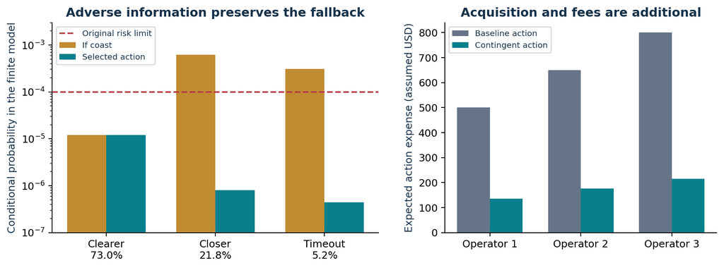

The originating plan preserves the action fallback after adverse or missing information. Probabilities and costs are supplied synthetic assumptions; bars show actual calculations. Acquisition and service fees are additional.

The independent checker passed 102 comparisons on this source example. Useful delivery here means a conforming finite decision package with explicit contingencies and accounting. A real operator has not accepted it, no sensor was tasked, and no flight authority was granted.

# 6 Fresh technical confirmation

The frozen compiler matched the exact conventional reference in every fresh case.

| Case family | Cases | Valid plans | Correct refusals | Reference agreement |
| --- | --- | --- | --- | --- |
| Shared information | 8 | 8 | 0 | 8 |
| Zero or negative value | 8 | 8 | 0 | 8 |
| Adverse information | 8 | 8 | 0 | 8 |
| Heterogeneous deadlines | 8 | 4 | 4 | 8 |
| Sensor prerequisites | 8 | 0 | 8 | 8 |
| Participant withdrawal | 8 | 8 | 0 | 8 |
| **Total** | **48** | **36** | **12** | **48** |

The evaluator inspected 594 operator branches, including 12 unreachable branches and ten unsafe reachable branches retained inside refused missions. A separate malformed-input diagnostic produced twelve structured refusals; those probes are not added to the primary 48-case denominator. No held-out case was repaired or discarded to improve the result.

Among valid plans, twenty have positive total gross information value, four have zero and twelve have negative value. Thirteen cases contain at least one individually negative buyer, a different quantity from the twelve with negative aggregate value. These are deliberately varied synthetic cases, so a population confidence interval or market success-rate interpretation would be inappropriate.

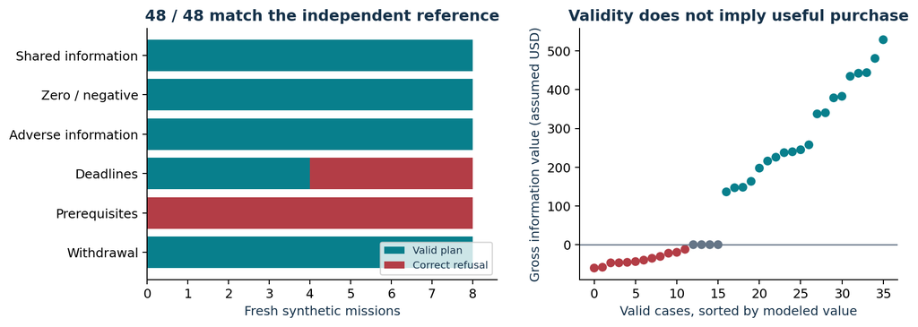

Fresh correctness includes refusals and economically unattractive plans. The exact conventional planner ties throughout. These counts describe a designed test cohort, not orbital or customer prevalence.

## 6.1 Why information can have negative cost value

The familiar argument that additional information cannot hurt assumes that the original decision remains available after observing. Physical action availability alone is insufficient under a branchwise posterior risk requirement. Adverse evidence can make a prior-safe action fail that same threshold; a forced timeout fallback can also be more expensive.

Let $a_i^0$ be the prior-optimal action and $A_i(y)$ the admissible action set after result $y$, including timing, posterior risk and the fixed timeout rule. If $a_i^0\in A_i(y)$ for every reachable branch, then

$$\min_{a\in A_i(y)} c_i(a)\leq c_i(a_i^0)
\quad\Rightarrow\quad
\mathbb E_y[c_i(a_i^*(y))]\leq c_i(a_i^0).$$

The condition is sufficient, not necessary. Its failure permits a negative value but does not force one. A post-confirmation diagnostic found that 90 of 130 accepted operator plans satisfy this inclusion condition, with zero violations of the bound. Four negative-total cases arise from the forced timeout rule alone; eight also remove baseline coast through posterior safety. Those diagnostic classifications explain the result; they are not new independent confirmation.

# 7 Commercial construction and complete accounting

## 7.1 A specified conditional order

The package fee is an illustrative **$80 per accepted operator package**, not a fixed discount from a human price. Shared acquisition costs $600 in the primary scenario, with a predeclared $100–$2,000 range. Customer adaptation costs $20. An operator participates only if its own modeled surplus is nonnegative and, when specified, its cash can cover the full fee, acquisition share, adaptation and its fallback reserve.

For a proposed set $S$ with equal acquisition shares, the declared buyer rule is

$$u_i(S)=(1-c)\left[q(V_i-p)-\frac{K}{|S|}\right]-a_i\geq0,$$

where $V_i$ is gross information value, $q=0.90$ is conditional semantic acceptance, $c=0.05$ is common package failure, $p=80$, $K=600$ and $a_i=20$. These probabilities are assumptions, not measured model performance. The roster is recomputed after withdrawals and after participants decline. The common package failure is distinct from the sensor’s no-result branch, already included in $V_i$.

Before commitment, each invited operator withdraws with assumed probability 0.10. On acceptance, a remaining fee balance defaults with assumed probability 0.03; a 30% service deposit has already been paid. Common package failure refunds both service deposits and acquisition pass-through, leaving a sunk acquisition loss with the provider. Individual nonacceptance or postcommit withdrawal refunds the service deposit but does not refund the already authorized acquisition share. This is a modeled contract design, whose enforceability and actual attractiveness have not been tested.

An exact finite event tree enumerates these events. It uses 44 positive-probability paths for the originating joint offer. There is no Monte Carlo sampling error in its arithmetic. Uncertainty about likelihoods, service effort and buyer behavior remains undiminished by exact enumeration.

## 7.2 Joint construction versus component ablations

| Configuration | Launch probability | Expected service collections | Complete A cost | Contribution before B/C |
| --- | --- | --- | --- | --- |
| No instrument, separate offers | 0 | $0.00 | $6.00 | −$6.00 |
| No instrument, coordination alone | 0 | $0.00 | $6.00 | −$6.00 |
| Instrument, individual procurement | 0 | $0.00 | $6.00 | −$6.00 |
| Instrument and shared arrangement | 0.81 | $157.30 | $134.47 | **$22.83** |
| Unrestricted competent expert | 0.81 | $157.30 | $134.47 | **$22.83** |

The first two rows remove a required component; they are not estimates of ordinary model behavior. The last row is essential: ordinary expertise with the same formulation and permissions reproduces the joint result. The positive mechanism is shared purchasing under the declared circumstances, not demonstrated algorithmic or AI-specific superiority.

## 7.3 Disjoint costs and the whole campaign

Cost A includes all assumed work needed for a paid outcome, including preparation, construction, correction, delivery, failed-case handling and support. The expected breakdown is:

| A activity | Expected USD per offered source cohort |
| --- | --- |
| Preliminary quotes for all three invitations | $6.00 |
| Construction, preparation and correction | $43.74 |
| Per-operator delivery | $46.98 |
| Failed or rejected handling | $3.41 |
| Support | $10.04 |
| Acquisition lost after common package failure | $24.30 |
| **Total A** | **$134.47** |

The assumed $0.80 Astra workload is already inside the $60 fixed delivery budget. It is not added a second time. Aggregate paid effort is modeled; arbitrary compulsory human-review minutes are not imposed. Actual unpaid engineering, residual customer attention and complete research cost are unmeasured. An additional unpriced provider cost above **$22.83 per offered originating cohort** erases the modeled expected operating contribution.

Cost B covers only extra assessment, rights/admission packaging, sharing and upkeep: $180 initially and $2 per compatible reuse in the threshold model. Cost C is optional extra research/calibration beyond the paid outcome, illustrated at $240. Primary policy spends neither because additional reusable benefit is unestablished. The study’s actual research effort is not relabeled as customer-funded delivery, and its true cost is not replaced by the illustrative C number.

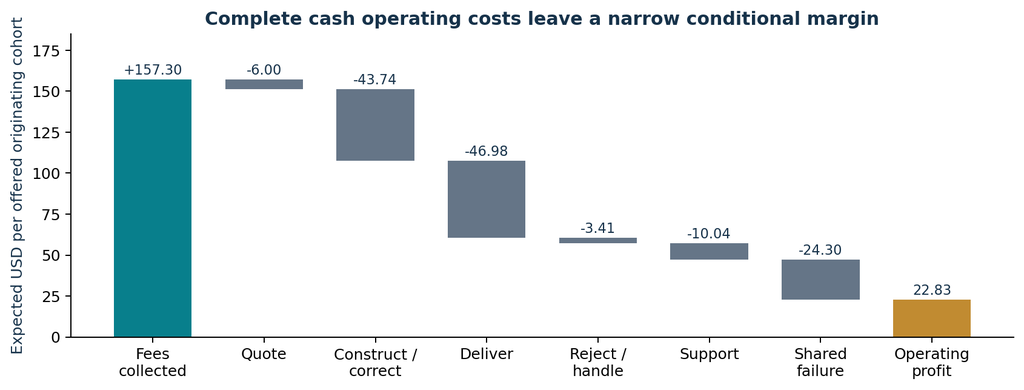

All modeled paid-job cash costs are charged once. The expected positive result is small relative to plausible uncertainty in delivery effort and common failure. Extra retention and R&D are separate decisions.

The same economic policy was then applied to all 48 fresh cases. It placed **zero orders** and collected **zero modeled service revenue**. Preliminary quoting/assessment still cost $346. Counting those rejected opportunities changes the modeled invitation campaign to **−$323.17** before B/C. The original positive illustration is preserved, but it does not establish a profitable general enterprise or a growing frontier of sellable work.

## 7.4 Human-service reference and buyer value

The BLS reports a May 2025 median aerospace-engineer annual wage of $134,960. (US Bureau of Labor Statistics 2026) Dividing by an assumed 2,080 hours gives the study’s hourly proxy of $64.8846. For the same finite decision-support scope, assumed work of 8–24 hours and burden multipliers of 1.5–2.5 give a human-production cost scenario of approximately **$779–$3,893**. Hours, burden and exact scope are estimates; this is not a consulting quote, flight certification price or proof that buyers would pay that amount.

The specialized shared-observation arrangement has no verified human-service market quote. Its primary price/participation test therefore uses explicit avoided-action-cost and willingness-to-pay hypotheses. The executable outside option is the supplied baseline/fallback plan. Free screening is a real-world alternative to qualify before a trial; it is not a separately priced and executed choice arm here. A sufficiently equipped conventional expert remains an equal technical competitor. Human cost, buyer savings and token issuance are not enterprise revenue.

## 7.5 Liquidity, failure and liabilities

The all-commit, all-accept, all-pay illustration receives $840: $600 is acquisition pass-through and $240 is service revenue. Complete A cost is $135, leaving $105 operating contribution. Seed capital of $1,500 ends as $1,605; after a $300 provider reserve, $1,305 is available. The buyers separately need $800, $950 and $1,100 under the stated cash timing, including the full fee and fallback reserves of $500, $650 and $800. Their actual balances are unknown.

An early ledger version reserved only the fee deposit on the buyer side. Review caught the omitted unpaid balance. The original source/results are preserved, the full-fee correction has a targeted regression, and primary expected profit is unchanged. This correction is part of the result, not an erased preparation error.

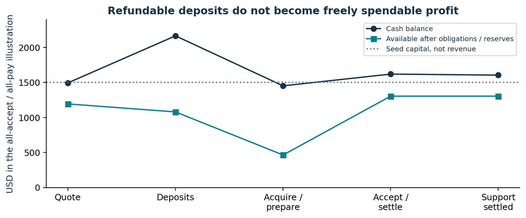

Cash and available funds differ throughout the modeled successful branch. Refundable deposits, unpaid obligations and reserves remain visible. These time steps are bookkeeping order, not measured end-to-end satellite-service latency.

For cumulative net cash flow excluding seed $F_t$, refundable liability $L_t$, unpaid obligations $O_t$ and reserve $R$, required seed is

$$S_{\rm req}=\max\left(0,\max_t\{L_t+O_t+R-F_t\}\right).$$

The zero-seed stress needs up to **$1,050** of financing and is unexecutable without it, despite positive expected source contribution. The worst source outcome loses $750. Raising conditional fee-balance default to 100% changes expected contribution to −$86.27. A postcommit withdrawal after acquisition leaves $20 in the explicit two-pay/one-withdraw branch, while retaining sunk cost and refund obligations. No default or refund is charged twice.

# 8 Transfer, selective retention and the next opportunity

The retained asset is a small executable compiler plus its scope contract, packaged as an exact two-file archive. It contains no protected cases or answers. It records version, license, source identities, prerequisites and limitations. The artifact is researcher-constructed and revised through development feedback. It is not a weight-trained model, a learned sensor probability matrix or evidence of autonomous scientific invention.

The existing source-qualified integration closure is reused unchanged: 29 vendor/lifecycle/native files within a 34-file bridge/driver closure. Its controls exercise member access, revocation, stale baseline, rights refusal, protected material and signed A/B/C accounting. **29 of 29** conformance controls pass. The conformance driver uses artificial admission economics; those controls do not admit this capability on empirical profit evidence. Native scientific scope remains refused rather than expanded to make the experiment pass.

## 8.1 A separate recipient actually executes the bytes

The recipient was selected by the lowest ID in the unfamiliar withdrawal category, not by its gain. It contains five latent states, three remaining operators and eighteen branches, compared with the source mission’s two states and nine branches. The exact retrieved archive runs in a separate isolated process. Thirteen transfer/process/parity checks pass, and the independent checker passes 174 comparisons.

| Fresh recipient quantity | Modeled USD |
| --- | --- |
| Baseline action expense | $236.84 |
| Contingent action expense | $100.60 |
| Aggregate gross information value | **$136.24** |
| Operator 0 information value | **−$16.03** |
| Operator 1 information value | $103.44 |
| Operator 3 information value | $48.83 |

An aggregate surplus does not demonstrate voluntary participation. The full-roster offer has an individually losing buyer, and the unchanged commercial policy declines it. Even the strongest voluntary subset supports only about $0.04 of acquisition expense at the fixed $80 fee; provider economics are negative there. None of the 25 predeclared price/acquisition diagnostic cells yields a viable recipient order. The successor therefore produces a justified stop, with a clear reason and preserved evidence.

An ordinary directory containing the same compiler and scope contract yields byte-identical output. This rejects a graph-specific value claim. The recipient can use the instrument without rebuilding it, but the study has not measured additional paid effort saved relative to a competent recipient already holding an equivalent conventional program.

## 8.2 Investment must be reachable before assessment

With incremental per-use cash saving $g$, upkeep $m$, initial B cost and optional extra C, strictly positive retained value requires

$$N(g-m)>B+C.$$

At $g=0$, the admission rule rejects retention before paying for an unattainable assessment. At the hypothetical $g=10$ and $m=2$, B=$180 needs 23 compatible uses; adding optional C=$240 needs 53. These are conditional break-even thresholds, not measured savings, guaranteed demand or admitted Alpha. Obsolescence, unfamiliar scope, negative transfer and uncertain reuse can only tighten the decision.

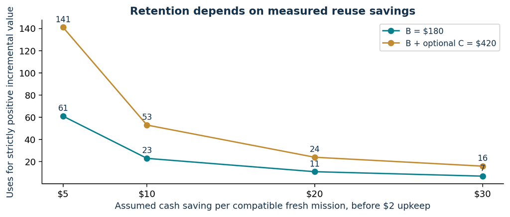

Reuse must repay additional costs against the recipient’s competent baseline. Incremental commercial savings remain unmeasured, so commercial admission is on hold. The research artifact remains available for inspection and reproduction.

# 9 Frontier operation and prompting: a proportionate test plan

Official documentation retrieved on 27 October 2026 identifies `gpt-6-astra` for demanding reasoning and research and `gpt-6.1-terra` for visual/computer-use work. Both expose tool use; project access and actual API entitlement were not established. Local presence checks found an installed SDK but no configured API key. ChatGPT subscription access does not establish API billing or a reproducible provider trial. (OpenAI 2026b, 2026c)

| Model | Standard input / output / cached input, USD per million tokens |
| --- | --- |
| `gpt-6-astra` | $10 / $50 / $1 |
| `gpt-6.1-terra` | $1 / $5 / $0.05 |
| `gpt-6.1-sol` | $2 / $10 / $0.10 |

These are tariffs, not observed study bills. The primary model uses short contexts without a cache benefit. Above 272,000 input tokens, Astra/Terra input/cache rates double and output rates rise by 1.5; cache writes and tool environments can cost extra. (OpenAI 2026a, 2026b, 2026c) The frozen assumed 30,000-input/10,000-output Astra workload costs $0.80 before additional tools, already included in A. Token counts, semantic accuracy and latency remain hypotheses.

The versioned reusable expert method is: capture original purpose and outside options; validate source meaning and units; enumerate adverse and missing-result branches; construct the minimal plan; independently check it; reconcile participation and funding; deliver or refuse with an auditable reason. The supplied prompt cards, authored after this software confirmation for the next matched trial, give U the same model/tool opportunities and usable context, E this checklist, and E+ the actual artifact. They were not the protocol behind the recorded 48 cases. Prompt sophistication does not set acceptance probabilities.

Primary simulated semantic acceptance is $q_U=q_E=q_{E+}=0.90$. A separate assumption grid includes equality, worse outcomes, positive gains, resource multipliers and retry costs. At matched resources it compares acceptance; at matched accepted quality it compares expected cost per accepted outcome. It does not treat a larger token budget as Operational Alpha.

For contracted price $P$, fee deposit fraction $f$, default probability $d$ on the remaining balance, effective per-package acceptance probability $Q_k=(1-c)q_k$ and complete expected attempted-job cost $a_k$, the collectible-price factor is $h=1-(1-f)d$. For an equal fixed roster, $Q_k$ is the expected accepted-fee fraction, not the probability that every package passes:

$$\pi_k=Q_kPh-a_k,\qquad
\Delta Q_{E-U}>\frac{a_E-a_U}{Ph}.$$

The primary deposit/default assumptions give $h=0.979$. For a fixed three-package illustration, $20 of extra expert cost on $240 of contracted fees requires **8.5121 percentage points** of additional effective per-package acceptance. Expressed as conditional semantic acceptance with common failure fixed at 5%, the required improvement is **8.9601 points**. An extra $30 requires 13.4401 conditional points, exceeding the remaining room from a 90% baseline. This marginal illustration holds the roster and other costs fixed; the full event tree separately models individual participation and withdrawals. The analytics correction and its prior version are preserved. The next matched trial should measure these quantities; this deterministic software experiment supplies no empirical frontier-model gain.

# 10 What the simulation usefully establishes

The conditional source example works only when information benefit, voluntary participation, supplier price, package effort and funding jointly fit. At the frozen $80 fee, the strongest source coalition’s acquisition ceiling is **$706.34**. At that exact boundary, the event tree still has positive expected contribution of $19.08. The ceiling is an inverse-price diagnostic derived after confirmation, not an observed supplier quote or a new primary result.

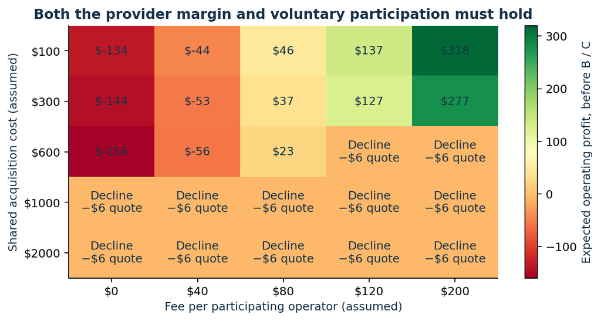

The source offer has a bounded commercial region. Larger fees can eliminate participation; inexpensive acquisition does not make a zero-fee service profitable. All cells are exact arithmetic under declared assumptions.

For equal shares, a voluntary subset $S$ has acquisition ceiling

$$K_{\max}(S)=|S|\left[q\left(\min_{i\in S}V_i-p\right)-\frac{a}{1-c}\right].$$

This gives the smallest useful next question: can an appropriate provider deliver timely, actionable information below the relevant ceiling, and do actual operators agree with the modeled values and obligations? More simulated draws cannot answer that question. The current fresh cohort’s zero orders and negative total invitation contribution make broad commercialization or compulsory training unsupported.

There are two kinds of uncertainty. Within a specified world, the exact event tree determines expected collections and losses. Across worlds, the probabilities, effort, buyer values, sensor behavior and contractual terms are uncertain assumptions. The latter dominate the result. No narrow numerical confidence band can convert them into empirical demand or physical assurance.

# 11 Practical operating blueprint

The general operating path extends the existing system without a competing registry:

1. **Discover and qualify the need.** Record beneficiary, original useful outcome, outside options, overlap with active work and the cheapest falsifier. Reject generic novelty claims when a conventional method already supplies the claimed capability.
2. **Freeze the commercial and technical contract.** Record quality, deadline, customer effort, permissions, price and failure handling. Separate supplied assumptions from observed evidence and preserve a source identity for each.
3. **Construct the smallest instrument.** Charge learning necessary for the paid outcome to A. Keep every adverse-result and timeout branch. Use an independent conventional implementation with equal information and rights.
4. **Gate each proposed offer.** Check mission-specific semantics, each participant’s utility, original fallback resources, funding prefixes and all obligations. Refuse zero-value information and unaffordable or incompatible offers.
5. **Accept and account.** Bind artifact, acceptance, source, permissions and cost records. Separate pass-through funds from earned fees; retain refunds, defaults and support. Treat actual missing billing as unknown.
6. **Retain selectively.** Assess incremental value against the recipient’s competent baseline before paying further admission cost. Rights-clear and version the actual executable asset. Withhold protected evaluation material and secrets.
7. **Transfer and revalidate.** Reuse stable identity and scope qualifications only when unchanged. Recheck the new mission’s inputs, outputs and meaning. Grant authority through its existing separate process. Preserve Jobs validator and settlement boundaries.
8. **Choose the next opportunity or stop.** A correct refusal is useful operating information. It is not a sale, new productive-frontier crossing or earned reinvestment capital.

The public research artifact is inspectable, while the fixture lifecycle exercises sharing among authorized `*.agent.agi.eth` identities. Those fixture checks do not establish live ENS authentication or production scope. The source-qualified journal and cost ledger remain authoritative for their existing boundaries. No token minting, wallet action or `$AGIALPHA` utility is counted as operating profit.

# 12 Next experiment and decision rules

The next live step is deliberately small: one observation provider and two or three operators supply a retrospective, permission-cleared event with an explicit shared-information opportunity. Obtain a scoped provider quote, the operators’ existing alternatives and the action/cash obligations they actually retain. No observation should be purchased merely to validate this paper’s example.

Run a shadow exercise first. Use an established conjunction-analysis process for domain inputs; the new instrument handles conditional packaging and accounting. Compare a competent conventional expert and the retained workflow with identical evidence, model access, budgets and permission to propose alternatives. Freeze the procedure, acceptance terms and budgets before revealing the held-out observation and outcome. Measure preparation, tokens/tools, failed attempts, correction, latency, customer effort and acceptance. Include one adverse/missing-result case and a buyer withdrawal. Record actual supplier and buyer terms before evaluating the outcome.

Before an authorized pilot, require original-purpose qualification, willing participants, a favorable complete expected contribution under their agreed terms, and sufficient funding for every cash prefix. After delivery, assess actual acceptance, collections and realized contribution separately. Test retention only if measured incremental recipient savings support reachable repayment before expected obsolescence. The source illustration’s $706.34 acquisition ceiling, $22.83 unpriced-cost tolerance and reuse thresholds provide falsifiable starting conditions, not approval to spend.

The current decision is to preserve the reusable research instrument, hold commercial admission, and seek the smallest price/value evidence capable of changing that decision. This completes the experimental cycle while leaving an explicit next question.

# 13 Reproducibility, provenance and remaining limits

The study is additive to main source `47c17f6aca6b1bb8779dd3e47d5ba5f8af3329f4`; it retains predecessor research `231834269599d85e49cfe1ca9917a1a874522d44` and native closure pins. Earlier thermal, numerical, manufacturing, ecological and operational studies remain unchanged. Source versions and ownership were inspected through issue 4850 before selecting this distinct lane.

The complete package includes source inputs, all 48 cases, candidate and reference outputs, process logs, preserved development failures/corrections, exact cost assumptions, the event tree, native transfer/accounting evidence, source hashes, this LaTeX project, an executive brief, an evidence companion and an English/French demonstration. The browser edition reproduces the manuscript. Canonical publication remains subject to the existing review and owner-controlled release process; a local reader or draft source link is not a deployed Pages edition.

Reproduction uses Python 3.11–3.13 for the study and the recorded Node/Pydantic/cryptography environment for the inherited integration. Core inference and finite economic enumeration require only the standard library. Scientific figure/document construction adds Matplotlib and the available LaTeX/Pandoc toolchain. The README provides commands with fresh output directories so original evidence is not overwritten.

The implementation was designed, coded, executed and written with ChatGPT assistance at the author’s request. Separate same-session agents handled discovery, calibration, reference evaluation and integration. Their separation improves review but is not external peer review. The stated author attribution does not imply that the author personally conducted every execution or has approved a final public deployment.

The study does not measure physical collision safety, sensor-model calibration, customer demand, enforceable agreements, live settlement, complete realized research cost, independent specialist training or sustained compounding. The exact conventional and ordinary-library ties are retained. The positive source example and negative fresh economic cohort are equally part of the result. What remains is a working instrument, a reproducible conditional argument and a more selective path to the next useful experiment.

# References

European Space Agency. 2021. “Blockchain Ecosystem for an Autonomous Consensus Mechanism of Federated Satellite Networks.” https://ideas.esa.int/core/servlet/hype/IMT?documentId=2d929ce255874896a6a09107ed58060f&documentTableId=7295537402235904412&templateName=&userAction=Browse.

———. 2023. “PhiSat-2 Mission Overview for the OrbitalAI Challenge.” https://challenges.philab.esa.int/wp-content/uploads/2023/02/Phisat-2_Mission_Overview_Web.pdf.

FAO and UNEP. 2022. “Amid Food and Climate Crises, Investing in Sustainable Food Cold Chains Crucial.” https://www.fao.org/newsroom/detail/amid-food-and-climate-crises-investing-in-sustainable-food-cold-chains-crucial/en.

MONTREAL.AI. 2026a. “Invent the Economy: Transformational Intelligence for Creating Viable Markets.” https://github.com/MontrealAI/AGI-Alpha-Agent-v0/blob/231834269599d85e49cfe1ca9917a1a874522d44/docs/Invent_the_Economy.tex.

———. 2026b. “SUCCESSOR Omega Public Integration Coordination, Issue 4850.” https://github.com/MontrealAI/AGI-Alpha-Agent-v0/issues/4850#issuecomment-6448140155.

———. 2026c. “Transformational Autonomous Enterprises: SUCCESSOR Omega Harness.” https://github.com/MontrealAI/AGI-Alpha-Agent-v0/blob/231834269599d85e49cfe1ca9917a1a874522d44/docs/papers/transformational-autonomous-enterprises-v1.tex.

———. 2026d. “Transformational Intelligence: Learning to Change the Game.” https://github.com/MontrealAI/AGI-Alpha-Agent-v0/blob/231834269599d85e49cfe1ca9917a1a874522d44/docs/Transformational_Intelligence.tex.

NASA Office of the Chief Engineer. 2026. “Spacecraft Conjunction Assessment and Collision Avoidance Best Practices Handbook: Volume 1.” https://nodis3.gsfc.nasa.gov/OCE_docs/OCE_51.pdf.

OpenAI. 2026a. “API Pricing.” https://developers.openai.com/api/docs/pricing.

———. 2026b. “GPT-6 Astra Model.” https://developers.openai.com/api/docs/models/gpt-6-astra.

———. 2026c. “GPT-6.1 Terra Model.” https://developers.openai.com/api/docs/models/gpt-6.1-terra.

Uriot, Thomas, Dario Izzo, Luís F. Simões, Rasit Abay, Nils Einecke, Sven Rebhan, Jose Martinez-Heras, Francesca Letizia, Jan Siminski, and Klaus Merz. 2020. “Spacecraft Collision Avoidance Challenge: Design and Results of a Machine Learning Competition.” *arXiv:2008.03069*. https://arxiv.org/abs/2008.03069.

US Bureau of Labor Statistics. 2026. “Aerospace Engineers: Occupational Outlook Handbook.” https://www.bls.gov/ooh/architecture-and-engineering/aerospace-engineers.htm.

US Environmental Protection Agency. 2026. “Tackling Emerging Contaminants.” https://www.epa.gov/water-infrastructure/tackling-emerging-contaminants-tec.